## Map Visualization

Here we are going to display the some Swedish demographic variables and public investments from 2011 to 2020 based on the municipal levels.

All the data comes from Statistics Sweden (SCB). The analysis is used for my master thesis named "The Impact of Swedish Public Finance Factors on the Local Real Estate Market — Based on the GMM PVAR Approach" at KTH.

```python
import osmnx as ox, geopandas as gpd
%matplotlib inline
ox.config(log_console=True, use_cache=True)
```

We download the shapefile and merge it with our dataset.

```python
Swe_link = "./gadm36_SWE_shp/gadm36_SWE_2.dbf"
Swe = gpd.read_file(Swe_link)
type(Swe)
```

```
geopandas.geodataframe.GeoDataFrame
```

```python
%matplotlib inline

import seaborn as sns
import pandas as pd
from pysal.lib import weights
import geopandas as gpd
import numpy as np
import matplotlib.pyplot as plt
from sklearn import cluster
from sklearn.linear_model import LinearRegression
import statsmodels.api as sm
from statsmodels.api import OLS
from sklearn import preprocessing
from sklearn.preprocessing import PolynomialFeatures
from sklearn.metrics import r2_score
from sklearn.model_selection import train_test_split
from sklearn.preprocessing import StandardScaler

from pandas.plotting import scatter_matrix

import seaborn as sns
```

```python
demo = pd.read_csv("./4demonew11.csv",header = 0)
```

```python
demo.head()
```

|  | Municipality | employ | educa | pop | inmi | edu_rate | ave_price |
| --- | --- | --- | --- | --- | --- | --- | --- |
| 0 | Upplands Väsby | 0.504264 | 0.739461 | 579.57 | 0.090433 | 0.240331 | 4145.9 |
| 1 | Vallentuna | 0.520483 | 0.708677 | 90.94 | 0.070134 | 0.261677 | 3914.7 |
| 2 | Österåker | 0.509145 | 0.718730 | 137.12 | 0.067417 | 0.256203 | 3971.3 |
| 3 | Värmdö | 0.519029 | 0.722353 | 94.03 | 0.071714 | 0.256547 | 4539.7 |
| 4 | Järfälla | 0.487248 | 0.725789 | 1372.70 | 0.089399 | 0.273913 | 4376.7 |

```python
demo.rename(columns = {'Municipality': 'NAME_2'},
           inplace = True)
```

```python
df1 = pd.merge(demo,Swe,how = 'left',on = ['NAME_2'])
```

```python
from geopandas import GeoDataFrame
```

```python
import mapclassify
```

```python
df1 = GeoDataFrame(df1)
```

```python
df1.head()
```

|  | NAME_2 | employ | educa | pop | inmi | edu_rate | ave_price | GID_0 | NAME_0 | GID_1 | NAME_1 | NL_NAME_1 | GID_2 | VARNAME_2 | NL_NAME_2 | TYPE_2 | ENGTYPE_2 | CC_2 | HASC_2 | geometry |
| --- | --- | --- | --- | --- | --- | --- | --- | --- | --- | --- | --- | --- | --- | --- | --- | --- | --- | --- | --- | --- |
| 0 | Upplands Väsby | 0.504264 | 0.739461 | 579.57 | 0.090433 | 0.240331 | 4145.9 | NaN | NaN | NaN | NaN | NaN | NaN | NaN | NaN | NaN | NaN | NaN | NaN | None |
| 1 | Vallentuna | 0.520483 | 0.708677 | 90.94 | 0.070134 | 0.261677 | 3914.7 | SWE | Sweden | SWE.15_1 | Stockholm | None | SWE.15.24_1 | None | None | Kommuner | Municipality | None | SE.ST.VL | POLYGON ((18.14253 59.47924, 18.14228 59.48373... |
| 2 | Österåker | 0.509145 | 0.718730 | 137.12 | 0.067417 | 0.256203 | 3971.3 | SWE | Sweden | SWE.15_1 | Stockholm | None | SWE.15.12_1 | None | None | Kommuner | Municipality | None | SE.ST.OS | MULTIPOLYGON (((18.56028 59.54097, 18.55917 59... |
| 3 | Värmdö | 0.519029 | 0.722353 | 94.03 | 0.071714 | 0.256547 | 4539.7 | SWE | Sweden | SWE.15_1 | Stockholm | None | SWE.15.25_1 | None | None | Kommuner | Municipality | None | SE.ST.VR | MULTIPOLYGON (((18.98028 59.48958, 18.98028 59... |
| 4 | Järfälla | 0.487248 | 0.725789 | 1372.70 | 0.089399 | 0.273913 | 4376.7 | SWE | Sweden | SWE.15_1 | Stockholm | None | SWE.15.6_1 | None | None | Kommuner | Municipality | None | SE.ST.JA | POLYGON ((17.73984 59.41447, 17.73954 59.41896... |

We listed three demographic variables based on the previous empirical studies just for examples. They are employment rate for those above 18 years old and have a stable job; the after upper secondary school education rate and the in-migration rate.

```python
df1["edu"] = df1["educa"]*100
```

```python
df1["edu"]
```

```
0      73.946143
1      70.867733
2      71.872984
3      72.235269
4      72.578928
         ...
285    74.690317
286    73.323457
287    73.483359
288    72.364772
289    72.903693
Name: edu, Length: 290, dtype: float64
```

```
(10.300838232040466, 24.83294606208801, 54.65011100769054, 69.7451755523683)
```

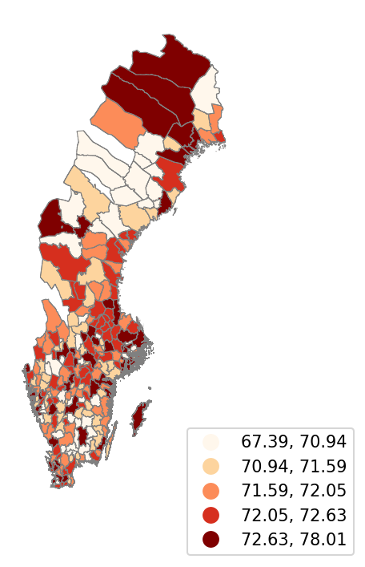

```python
fig, ax = plt.subplots(1, figsize=(5.5, 5.5), dpi=150)

df1.plot(
    column='edu', cmap='OrRd', scheme='Quantiles', linewidth=0.5, edgecolor='0.5',legend_kwds = {"bbox_to_anchor" : (1.6,0.2),"borderaxespad" : 1},legend = True, ax=ax)
ax.axis('off')
```

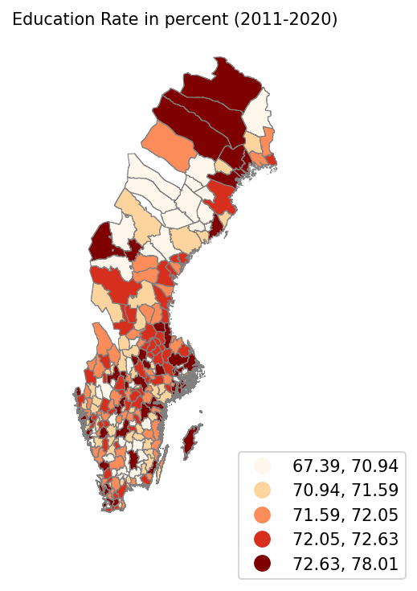

```python
ax.set_title('Education Rate in percent (2011-2020)', fontdict={'fontsize': '10', 'fontweight': '1'})
fig
```

```python
df1["emplo"] = df1["employ"]*100
```

```
(10.300838232040466, 24.83294606208801, 54.65011100769054, 69.7451755523683)
```

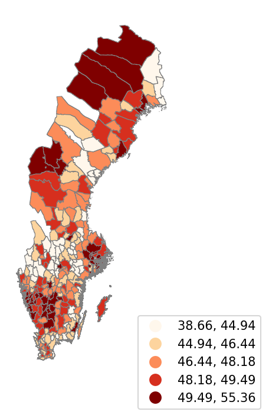

```python
fig, ax = plt.subplots(1, figsize=(5.5, 5.5), dpi=150)

df1.plot(
    column='emplo', cmap='OrRd', scheme='Quantiles', linewidth=0.5, edgecolor='0.5',legend_kwds = {"bbox_to_anchor" : (1.6,0.2),"borderaxespad" : 1},legend = True, ax=ax)
ax.axis('off')
```

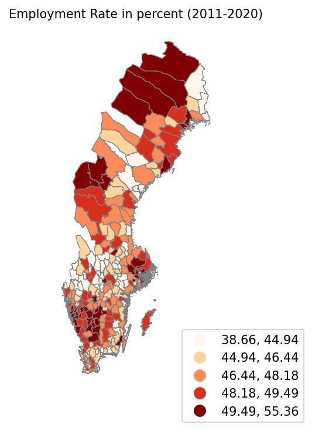

```python
ax.set_title('Employment Rate in percent (2011-2020)', fontdict={'fontsize': '10', 'fontweight': '1'})
fig
```

```python
df1["inmig"] = df1["inmi"]*100
```

```
(10.300838232040466, 24.83294606208801, 54.65011100769054, 69.7451755523683)
```

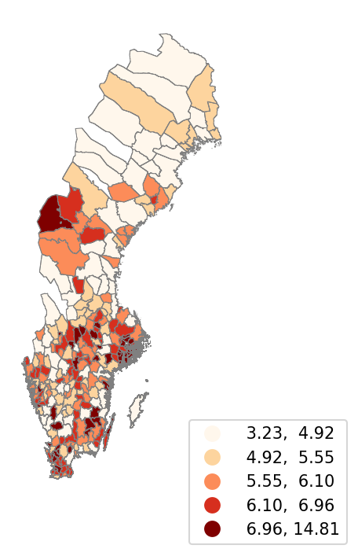

```python
fig, ax = plt.subplots(1, figsize=(5.5, 5.5), dpi=150)

df1.plot(
    column='inmig', cmap='OrRd', scheme='Quantiles', linewidth=0.5, edgecolor='0.5',legend_kwds = {"bbox_to_anchor" : (1.6,0.2),"borderaxespad" : 1},legend = True, ax=ax)
ax.axis('off')
```

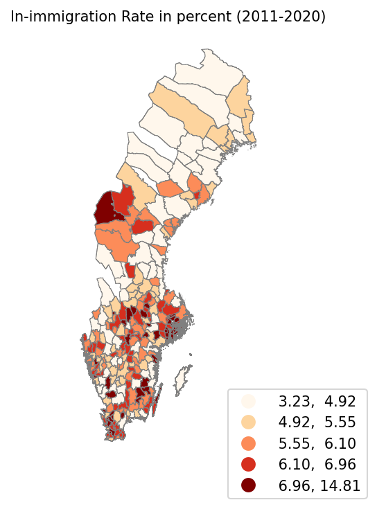

```python
ax.set_title('In-immigration Rate in percent (2011-2020)', fontdict={'fontsize': '10', 'fontweight': '1'})
fig
```

We can show more details about the immigrations in Sweden by the line chart.

```python
df1 = pd.read_csv("./immigar.csv",header = 0)
```

```python
num1=df1.loc[:,'out_mi']
```

```python
num2=df1.loc[:,'in_mi']
```

```python
plt.figure(figsize=(30,30), dpi=3000)
```

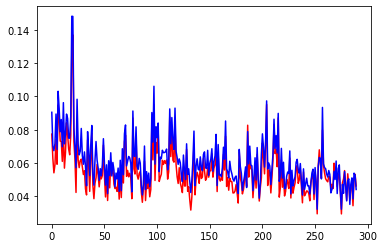

```python
plt.plot(range(len(num1)), num1, label='Out-migration Rate in percent (2011-2020)',color="r")
plt.plot(range(len(num1)), num2, label='In-migration Rate in percent (2011-2020)',color="b")
```

The red lines are the out-migration rate in Sweden from 2011 to 2020, while the blue lines are the in-migration rate, we can see that their trends are similar, but overall more people move in.

Public investments in Sweden can be seen as the attractive factors for consumers to buy a house. So we listed six main types of government costs here to do some basic data visualization.

```python
public = pd.read_csv("./5.csv",header = 0)
```

```python
public.head()
```

|  | year | poli | infras | cul | edu | heal | bus |
| --- | --- | --- | --- | --- | --- | --- | --- |
| 0 | 2011 | 830.077570 | 4831.609440 | 2637.231922 | 25679.99591 | 23269.53607 | 3563.885847 |
| 1 | 2012 | 833.394751 | 4965.291529 | 2744.088469 | 26196.28606 | 24143.22454 | 3313.349377 |
| 2 | 2013 | 836.273789 | 4957.716503 | 2786.263553 | 26773.77466 | 24930.82600 | 3373.919590 |
| 3 | 2014 | 921.732431 | 5071.371429 | 2861.388183 | 27570.16576 | 25627.27549 | 3377.132576 |
| 4 | 2015 | 907.307356 | 5038.995353 | 2920.202558 | 28438.08953 | 26466.28533 | 3381.645762 |

```python
public.rename(columns = {'poli': 'political activities'},
           inplace = True)
```

```python
public.rename(columns = {'cul': 'culture activities'},
           inplace = True)
```

```python
public.rename(columns = {'edu': 'pedagogical activities'},
           inplace = True)
```

```python
public.rename(columns = {'heal': 'health care'},
           inplace = True)
```

```python
public.rename(columns = {'bus': 'business activities'},
           inplace = True)
```

```python
public.rename(columns = {'infras': 'infrastructure'},
           inplace = True)
```

```python
import matplotlib.pyplot as plt
```

```python
public.head()
```

|  | year | political activities | infrastructure | culture activities | pedagogical activities | health care | business activities |
| --- | --- | --- | --- | --- | --- | --- | --- |
| 0 | 2011 | 830.077570 | 4831.609440 | 2637.231922 | 25679.99591 | 23269.53607 | 3563.885847 |
| 1 | 2012 | 833.394751 | 4965.291529 | 2744.088469 | 26196.28606 | 24143.22454 | 3313.349377 |
| 2 | 2013 | 836.273789 | 4957.716503 | 2786.263553 | 26773.77466 | 24930.82600 | 3373.919590 |
| 3 | 2014 | 921.732431 | 5071.371429 | 2861.388183 | 27570.16576 | 25627.27549 | 3377.132576 |
| 4 | 2015 | 907.307356 | 5038.995353 | 2920.202558 | 28438.08953 | 26466.28533 | 3381.645762 |

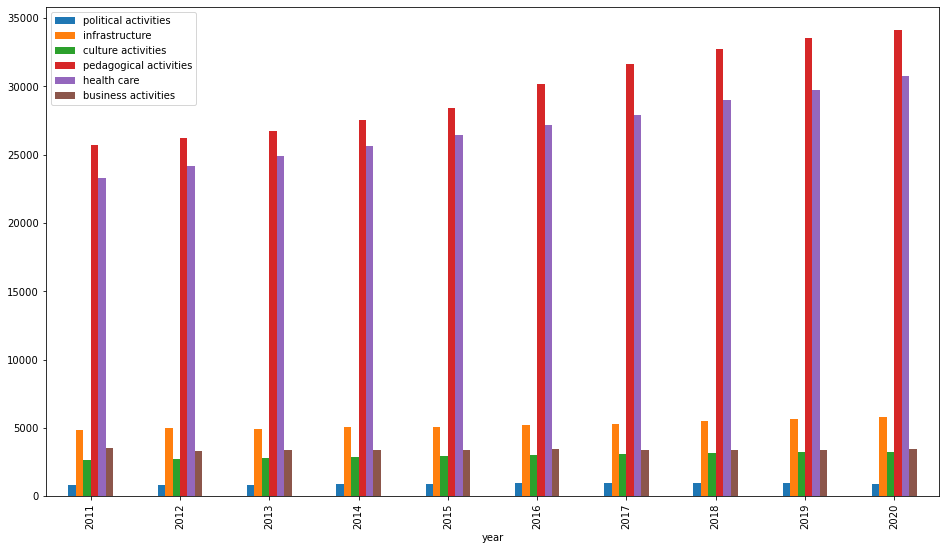

```python
public.plot(kind='bar',figsize=(16,9),

x = 'year',

y=['political activities', 'infrastructure',"culture activities","pedagogical activities","health care","business activities"])

plt.show()
```

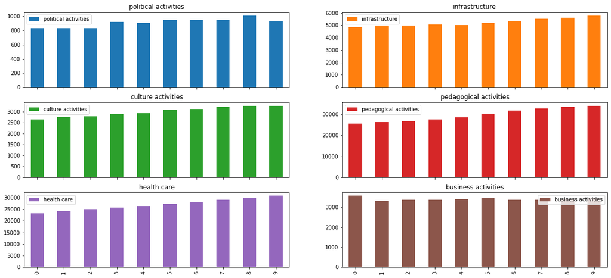

```python
public.plot(kind='bar',

y=['political activities', 'infrastructure',"culture activities","pedagogical activities","health care","business activities"],

subplots=True,

layout=(3, 2),

figsize=(20, 9))

plt.show()
```

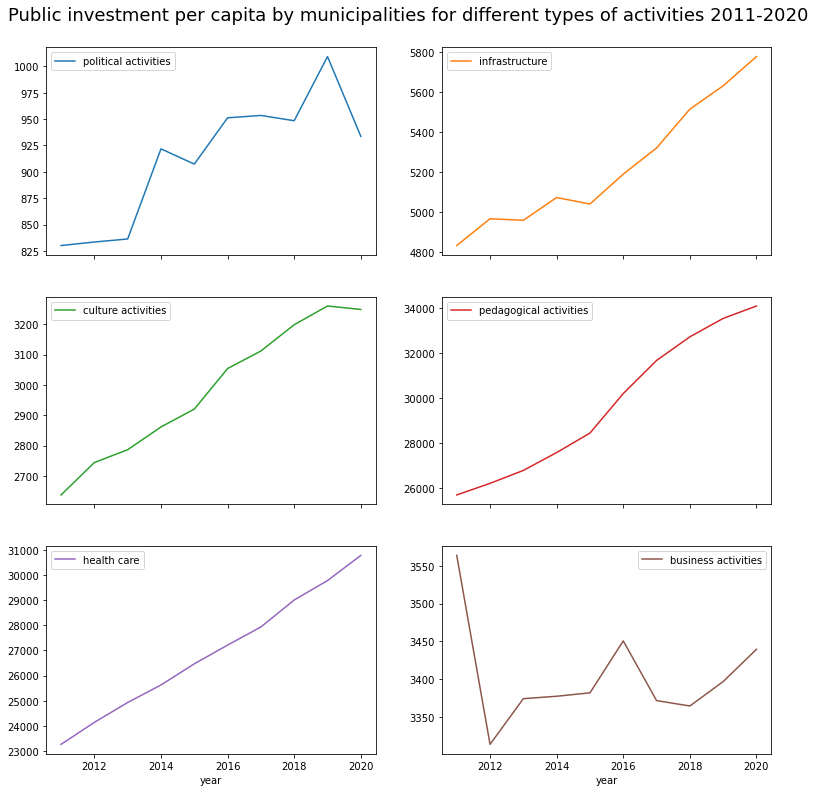

```python
public.plot(kind='line',

x = "year",

y=['political activities', 'infrastructure',"culture activities","pedagogical activities","health care","business activities"], #4个变量可视化

subplots=True,

layout=(3, 2),

figsize=(13, 13))

plt.title("Public investment per capita by municipalities for different types of activities 2011-2020",fontsize = 18, y = 3.5, x =-0.1)

plt.show()
```

```python
public = pd.DataFrame(public)
```

```python
public.describe(include='all')
```

|  | year | political activities | infrastructure | culture activities | pedagogical activities | health care | business activities |
| --- | --- | --- | --- | --- | --- | --- | --- |
| count | 10.00000 | 10.000000 | 10.000000 | 10.000000 | 10.000000 | 10.000000 | 10.000000 |
| mean | 2015.50000 | 912.464481 | 5229.036339 | 2982.236480 | 29692.954342 | 26912.011876 | 3403.202371 |
| std | 3.02765 | 60.771412 | 318.260043 | 223.508657 | 3175.350901 | 2478.030905 | 68.328431 |
| min | 2011.00000 | 830.077570 | 4831.609440 | 2637.231922 | 25679.995910 | 23269.536070 | 3313.349377 |
| 25% | 2013.25000 | 854.032181 | 4983.717485 | 2805.044710 | 26972.872435 | 25104.938373 | 3372.008090 |
| 50% | 2015.50000 | 927.669756 | 5129.827520 | 2987.039838 | 29320.222235 | 26838.267325 | 3379.389169 |
| 75% | 2017.75000 | 950.492502 | 5464.532639 | 3176.801376 | 32468.166948 | 28732.375103 | 3428.689532 |
| max | 2020.00000 | 1009.243735 | 5775.588962 | 3260.228278 | 34106.709310 | 30771.217720 | 3563.885847 |